# act_report

## Report: act_report

The algorithm works better on pictures that are clear and with better focus, the poorest classified dog breed's [picture](https://pbs.twimg.com/media/CUBl6IwVAAA9_zT.jpg) was a bit blurry and the dog was not clearly visible, which might have been the reason for the poor classification and once more to make the statement even more concrete the [dog](https://pbs.twimg.com/media/CsVO7ljW8AAckRD.jpg) that was classified as objets had a not so great picture. But that does not take away the fact that the picture was adorable.

The top rated dog really deserved the rating as him/her and his/her owner really went out of their way to put on a presentation and for him/her to sit through the time to get the costume on really proves he/she lived up to the group he/she belongs. [He/she](https://pbs.twimg.com/media/CmgBZ7kWcAAlzFD.jpg) is a REALLY GOOD DOG, BRENT!!

There is one dog in particular associated with the highest retweets, reply count, and like count. It is highly likely that the more retweets a tweet gets, the more people engage and the more people are likely interested in the tweet. Unfortunately the picture of this specific dog is not available for us to see what about the dog got people's thumbs working, but I bet he/she potrayed qualities of a Great dog.

There is a lot of variation when it comes to the algorithm classifying the dog images poorly, compared to when the algorithm classifies the dog images correctly, as seen in the bar charts below.

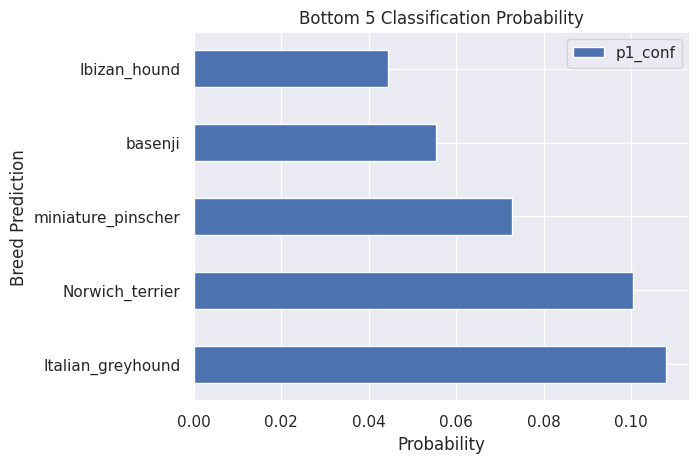

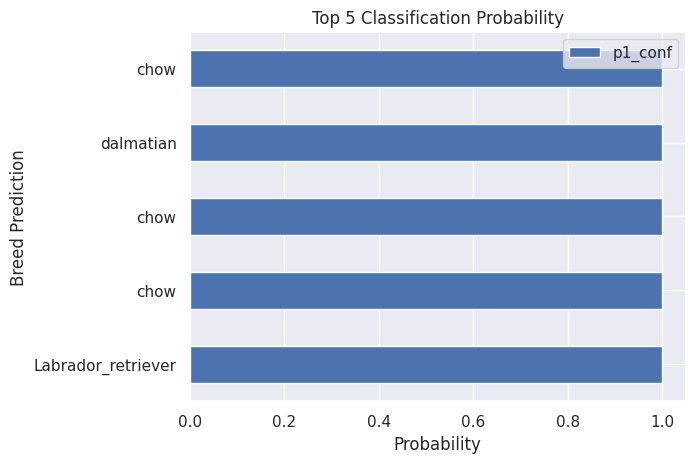